# Tales of Game Series: JP vs NA Ratings

Jason Chhay

8/27/2020

#### [Back to projects page](https://jwchhay.github.io/projects.html)

Note: most of my information comes from the Wikipedia article for the game series (https://en.wikipedia.org/wiki/Tales_(video_game_series).

One of my favorite video game series is the “Tales of” series, published by Namco Bandai who has published other popular games like Soul Calibur, Pac-Man, and Dark Souls, among others. This series is a JRPG series and is highly regarded in Japan, ranking as the 3rd biggest RPG series in that country behind Final Fantasy and Dragon Quest.

I’ve played my fair share of games in the series ever since I was in junior high. Out of the 18 released games in the series, I’ve beaten 6 of them. They’re all lengthy games, especially if you try to discover and unlock everything that each game has to offer (in particular I’ve logged in roughly 150 hours in one of my favorites: Tales of Symphonia). The average game takes around 40 hours to beat, and I think I have around 300+ hours in the whole series. It’s safe to say that I like the series.

There’s a famous video game magazine in Japan called Famitsu, and they publish scores that get released in that country. As said in this article for Ghost of Tsushima (https://gearnuke.com/ghost-of-tsushima-gets-perfect-score-from-famitsu-third-western-game-to-reach-this-milestone/), “The review criteria at Famitsu is different compared to other publications where four editors offer their opinion on a game and each score them individually. The scores are then combined.”

For America, Gamerankings was a popular game review source, except they started on a website and they are a review aggregator. Eventually, they merged into Metacritic in 2019, which is a similar site. Some people use these websites as a basis for reviews, but since they aggregate reviews, certain games can be heavily skewed just from people giving games 0’s to perfect scores.

I wanted to see how people within Japan and NA rated this game series, and compare them to my rankings of the 6 games I played. So, I hopped onto Excel and created this chart.

Some notes about what I made:

- Shown are games that were both released in NA and in Japan, since some games are Japan-exclusive.
- The x-axis contains the name of the game, the release date for both countries, and what system they’re on.
- Some reviews were missing for Metacritic and Gamerankings; decimal values are averages of both site’s ratings while whole numbers are just whatever value I could find.
- Tales of Zestiria was released on both the PS3 and PS4; JP rating is based on PS3 while the NA rating is PS4 (since I couldn’t find a rating for PS3). Looking up the version differences, both versions of the game are essentially the same, minus some graphical components like 1080p, etc.

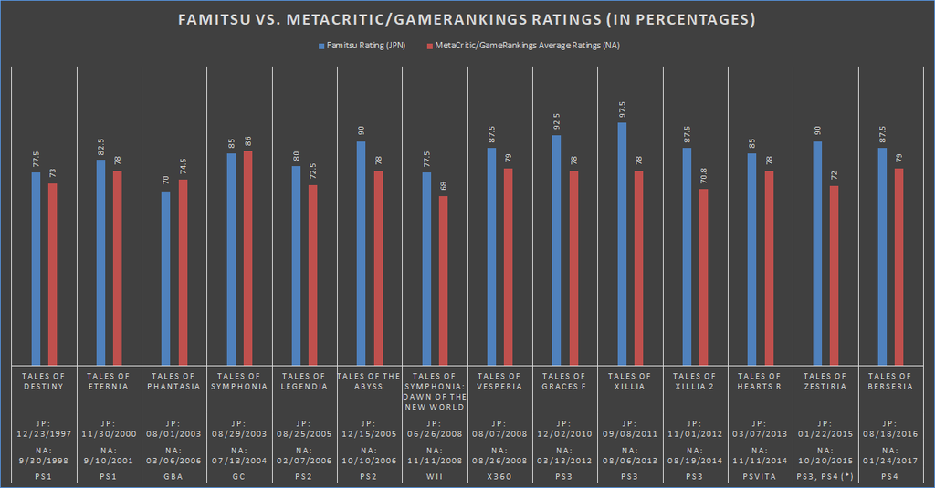

*Please use this link to see the image in higher resolution (https://i.imgur.com/vXxXGgN.png)*

Just at a glance, Famitsu rates their favorite Tales game as Tales of Xillia, while Metacritic/GameRankings rates their favorite as Tales of Symphonia. Huh, that’s interesting.

I thought Xillia was good but I didn’t expect it to be so highly rated. That game also has the highest disparity out of the two ratings.

Meanwhile, Tales of Symphonia is the highest rated Tales game from an NA perspective, and it even beats out Famitsu in percentage albeit barely. I have no idea why might be.

Anyhow, I just wanted to quickly glance at what the ratings are, I don’t have much analysis to do here besides investigating why JP liked Tales of Xillia so much. Also, I also just wanted to test out the graphics you can get from Excel, since I’ve been working with it recently for a while and I’m trying to get more comfortable using more features. For quick visuals, it’s very nifty.

Cheers.